# 3.1. Model Evaluation using k-fold CV

#### Overfitting : a common example

*Let's say we have two students who are preparing for the same test- one student makes an effort to understand the general concepts that will be tested while the other student simply memorizes every example from the relevant homework sets. If the test contains new problems that weren't on the homework but are still related to the concepts discussed, the former student will perform much better on the test than the student who memorized the homework answers.*

In machine learning, we use the term overfitting to describe whether or not an algorithm has read too much into the data we provided as examples, or whether it was capable of generalizing the concepts we were trying to teach it.

For machine learning problems with limited data, it's desirable to maximize the amount of data used to actually train your model. However, you must still hold out sufficient data for the validation set to evaluate model performance. In such situations, K-folds cross validation may come in handy.

Remember, we'll teach the computer using the data we have available, but ideally the algorithm should work just as well with new data too. This is important because we want to ensure that our algorithm is able to generalize its learning from the given examples.

The most important thing you can do to properly evaluate your model is to not train the model on the entire dataset. Remember: **do not train the model on the entire dataset**.

As discussed previously, it's important to use new data when evaluating our model to check chances of overfitting to the training set. However, sometimes it's useful to evaluate our model as we're building it.

## Importing the libraries

```python
import numpy as np
import matplotlib.pyplot as plt
import pandas as pd
```

## Importing the dataset

```python
dataset = pd.read_csv('Social_Network_Ads.csv')
X = dataset.iloc[:, :-1].values
y = dataset.iloc[:, -1].values
```

## Splitting the dataset into the Training set and Test set

```python
from sklearn.model_selection import train_test_split
X_train, X_test, y_train, y_test = train_test_split(X, y, test_size = 0.25, random_state = 0)
```

## Feature Scaling

```python
from sklearn.preprocessing import StandardScaler
sc = StandardScaler()
X_train = sc.fit_transform(X_train)
X_test = sc.transform(X_test)
```

## Training the Logistic Regression model on the Training set

```python
from sklearn.linear_model import LogisticRegression

classifier = LogisticRegression() # instanciating

classifier.fit(X_train, y_train)  #fitting logistic regression
```

```
LogisticRegression(C=1.0, class_weight=None, dual=False, fit_intercept=True,
                   intercept_scaling=1, l1_ratio=None, max_iter=100,
                   multi_class='auto', n_jobs=None, penalty='l2',
                   random_state=None, solver='lbfgs', tol=0.0001, verbose=0,
                   warm_start=False)
```

## Making the Confusion Matrix

```python
from sklearn.metrics import confusion_matrix, accuracy_score
y_pred = classifier.predict(X_test)

cm = confusion_matrix(y_test, y_pred)

print(cm)

print("Accuracy Score:", accuracy_score(y_test, y_pred))
```

```
[[65  3]
 [ 8 24]]
Accuracy Score: 0.89
```

## Model Evaluation using k-Fold Cross Validation

```python
from sklearn.model_selection import cross_val_score

accuracies = cross_val_score(estimator = classifier, X = X_train, y = y_train, cv = 10)   #no of folds, i.e., k =10

print(accuracies)
```

```
[0.76666667 0.86666667 0.73333333 0.86666667 0.7        0.66666667
 0.83333333 0.93333333 0.96666667 0.9       ]
```

```python
print("Accuracy: {:.2f} %".format(accuracies.mean()*100))
```

```
Accuracy: 82.33 %
```

```python
print("Standard Deviation: {:.2f} %".format(accuracies.std()*100))
```

```
Standard Deviation: 9.67 %
```

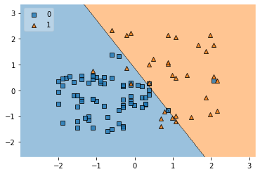

```python
import matplotlib.pyplot as plt
from mlxtend.plotting import plot_decision_regions
# import matplotlib.gridspec as gridspec
%matplotlib inline

plot_decision_regions(X=X_test, y=y_test, clf=classifier, legend=2)
```

## Visualising the Test set results

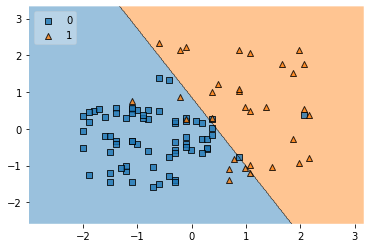

```python
import matplotlib.pyplot as plt
from mlxtend.plotting import plot_decision_regions
# import matplotlib.gridspec as gridspec
%matplotlib inline

plot_decision_regions(X=X_test, y=y_test, clf=classifier, legend=2)
```